# Practical Machine Learning Project

DAB

February 22, 2017

# Background

Using devices such as Jawbone Up, Nike FuelBand, and Fitbit it is now possible to collect a large amount of data about personal activity relatively inexpensively. These type of devices are part of the quantified self movement â a group of enthusiasts who take measurements about themselves regularly to improve their health, to find patterns in their behavior, or because they are tech geeks. One thing that people regularly do is quantify how much of a particular activity they do, but they rarely quantify how well they do it. In this project, your goal will be to use data from accelerometers on the belt, forearm, arm, and dumbell of 6 participants. They were asked to perform barbell lifts correctly and incorrectly in 5 different ways. More information is available from the website here: http://groupware.les.inf.puc-rio.br/har (see the section on the Weight Lifting Exercise Dataset).

# What you should submit

The goal of your project is to predict the manner in which they did the exercise. This is the “classe” variable in the training set. You may use any of the other variables to predict with. You should create a report describing how you built your model, how you used cross validation, what you think the expected out of sample error is, and why you made the choices you did. You will also use your prediction model to predict 20 different test cases.

# Course Project Prediction Quiz Portion

Apply your machine learning algorithm to the 20 test cases available in the test data above and submit your predictions in appropriate format to the Course Project Prediction Quiz for automated grading.

# Reproducibility

Due to security concerns with the exchange of R code, your code will not be run during the evaluation by your classmates. Please be sure that if they download the repo, they will be able to view the compiled HTML version of your analysis.

## Download and read in the training and Testing data

```r
train_URL <-"https://d396qusza40orc.cloudfront.net/predmachlearn/pml-training.csv"
test_URL <- "https://d396qusza40orc.cloudfront.net/predmachlearn/pml-testing.csv"
train_dest <- "c:/R/Practical Machine Learning/data/pml-training.csv"
test_dest  <- "c:/R/Practical Machine Learning/data/pml-testing.csv"
if (!file.exists("c:/R/Practical Machine Learning/data")) {
  dir.create("c:/R/Practical Machine Learning/data")
}
if (!file.exists(train_dest)) {
  download.file(train_URL, destfile=train_dest)
}
if (!file.exists(test_dest)) {
  download.file(test_URL, destfile=test_dest)
}

#read in training and testing data
train_in <- read.csv("c:/R/Practical Machine Learning/data/pml-training.csv")
test_in <- read.csv("c:/R/Practical Machine Learning/data/pml-testing.csv")
```

## Load packages

```r
library(caret)
```

```r
library(rpart)
library(rpart.plot)
```

```r
library(RColorBrewer)
library(rattle)
```

```r
library(randomForest)
```

# Clean up data set

### Remove vars with near zero variance

```r
no_vars<- nearZeroVar(train_in)
d_train_in <- train_in[, -no_vars]
dim(d_train_in)
```

```
## [1] 19622   100
```

### Remove vars 90% or more NULL

```r
null_90    <- sapply(d_train_in, function(x) mean(is.na(x))) > 0.90
d_train_in <- d_train_in[, null_90==FALSE]
dim(d_train_in)
```

```
## [1] 19622    59
```

### remove variables in columns 1-5, these vars are not measurements but identifications and times

```r
d_train_in <- d_train_in[, -(1:5)]
dim(d_train_in)
```

```
## [1] 19622    54
```

```r
split <- createDataPartition(d_train_in$classe, p=0.7, list=FALSE)
d_train <- d_train_in[split, ]
d_test <- d_train_in[-split, ]
```

# Create Model

##### Try out a Cart decision tree, a random forest, and a ensamble of gbm and lda. The training data set has been devided 70%/30% into a train and text sets. method will be to create each of the three models usin the training set and evaluate on the testing set, compare residuals and apply the best model to the 20 test cases.

### create a first model - Decision Tree

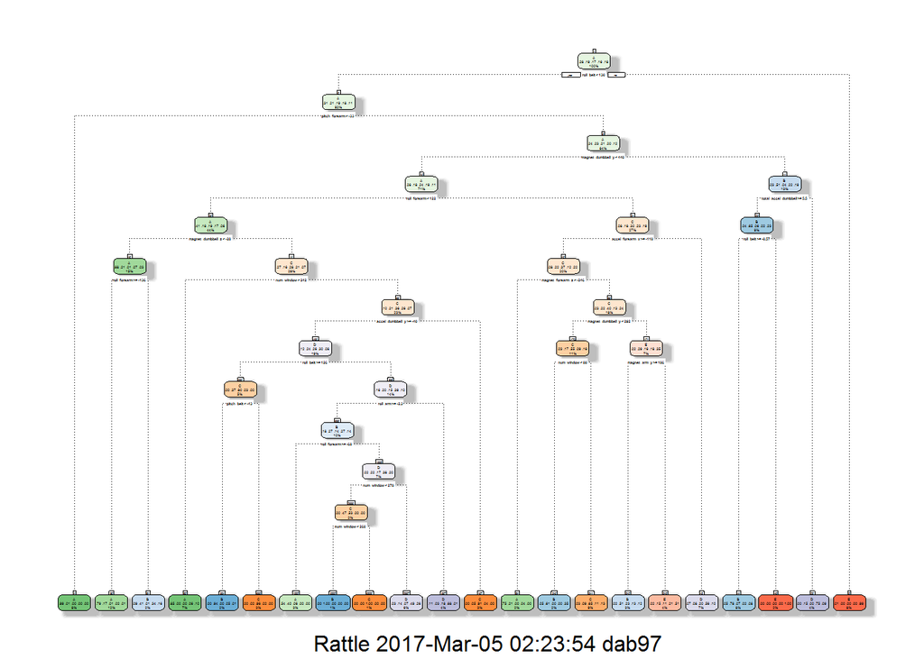

```r
set.seed(1)
model_rpart <- rpart(classe~.,data=d_train,method="class")
fancyRpartPlot(model_rpart)
```

### evaluate the decision tree with the d_test data set

```r
pred_rpart <- predict(model_rpart, d_test, type = "class")
rpart_res <- confusionMatrix(pred_rpart, d_test$classe)
rpart_res
```

```
## Confusion Matrix and Statistics
##
##           Reference
## Prediction    A    B    C    D    E
##          A 1529  220   13   50   53
##          B   58  669   76   91  111
##          C   12   85  737   58   68
##          D   68  143  175  696  166
##          E    7   22   25   69  684
##
## Overall Statistics
##
##                Accuracy : 0.7332
##                  95% CI : (0.7217, 0.7445)
##     No Information Rate : 0.2845
##     P-Value [Acc > NIR] : < 2.2e-16
##
##                   Kappa : 0.6616
##  Mcnemar's Test P-Value : < 2.2e-16
##
## Statistics by Class:
##
##                      Class: A Class: B Class: C Class: D Class: E
## Sensitivity            0.9134   0.5874   0.7183   0.7220   0.6322
## Specificity            0.9202   0.9292   0.9541   0.8878   0.9744
## Pos Pred Value         0.8198   0.6657   0.7677   0.5577   0.8476
## Neg Pred Value         0.9639   0.9037   0.9413   0.9422   0.9216
## Prevalence             0.2845   0.1935   0.1743   0.1638   0.1839
## Detection Rate         0.2598   0.1137   0.1252   0.1183   0.1162
## Detection Prevalence   0.3169   0.1708   0.1631   0.2121   0.1371
## Balanced Accuracy      0.9168   0.7583   0.8362   0.8049   0.8033
```

### Create a second model - Random Forest

```r
set.seed(1)
model_rf<-randomForest(classe ~ ., data=d_train)
```

### evaluate the random forest model with the d_test data set

```r
pred_rf <- predict(model_rf, d_test, type = "class")
rf_res <- confusionMatrix(pred_rf, d_test$classe)
rf_res
```

```
## Confusion Matrix and Statistics
##
##           Reference
## Prediction    A    B    C    D    E
##          A 1673    4    0    0    0
##          B    0 1130    2    0    0
##          C    0    5 1024    1    0
##          D    0    0    0  963    2
##          E    1    0    0    0 1080
##
## Overall Statistics
##
##                Accuracy : 0.9975
##                  95% CI : (0.9958, 0.9986)
##     No Information Rate : 0.2845
##     P-Value [Acc > NIR] : < 2.2e-16
##
##                   Kappa : 0.9968
##  Mcnemar's Test P-Value : NA
##
## Statistics by Class:
##
##                      Class: A Class: B Class: C Class: D Class: E
## Sensitivity            0.9994   0.9921   0.9981   0.9990   0.9982
## Specificity            0.9991   0.9996   0.9988   0.9996   0.9998
## Pos Pred Value         0.9976   0.9982   0.9942   0.9979   0.9991
## Neg Pred Value         0.9998   0.9981   0.9996   0.9998   0.9996
## Prevalence             0.2845   0.1935   0.1743   0.1638   0.1839
## Detection Rate         0.2843   0.1920   0.1740   0.1636   0.1835
## Detection Prevalence   0.2850   0.1924   0.1750   0.1640   0.1837
## Balanced Accuracy      0.9992   0.9958   0.9984   0.9993   0.9990
```

### Create a third model - Ensamble

```r
set.seed(1)
# Gradient Boosting
model_gbm<- train(classe~.,data=d_train,method="gbm")
```

#### evaluate the gradient boosting model with the d_test data set

```r
pred_gbm <- predict(model_gbm, d_test)
gbm_res <- confusionMatrix(pred_gbm, d_test$classe)
gbm_res
```

[output not shown]

##### create a Linear Discriminant Analysis model

```r
set.seed(1)
#Linear Discriminant Analysis
model_lda <- train(classe ~ ., data=d_train, method="lda")
```

#### evaluate the LDA model with the d_test data set

```r
pred_lda <- predict(model_lda, d_test)
lda_res <- confusionMatrix(pred_lda, d_test$classe)
lda_res
```

```
## Confusion Matrix and Statistics
##
##           Reference
## Prediction    A    B    C    D    E
##          A 1390  169  112   55   46
##          B   50  722   91   44  151
##          C  106  164  663  115   95
##          D  122   37  130  706  105
##          E    6   47   30   44  685
##
## Overall Statistics
##
##                Accuracy : 0.7079
##                  95% CI : (0.6961, 0.7195)
##     No Information Rate : 0.2845
##     P-Value [Acc > NIR] : < 2.2e-16
##
##                   Kappa : 0.6301
##  Mcnemar's Test P-Value : < 2.2e-16
##
## Statistics by Class:
##
##                      Class: A Class: B Class: C Class: D Class: E
## Sensitivity            0.8303   0.6339   0.6462   0.7324   0.6331
## Specificity            0.9093   0.9292   0.9012   0.9199   0.9736
## Pos Pred Value         0.7844   0.6824   0.5801   0.6418   0.8436
## Neg Pred Value         0.9310   0.9136   0.9235   0.9461   0.9217
## Prevalence             0.2845   0.1935   0.1743   0.1638   0.1839
## Detection Rate         0.2362   0.1227   0.1127   0.1200   0.1164
## Detection Prevalence   0.3011   0.1798   0.1942   0.1869   0.1380
## Balanced Accuracy      0.8698   0.7815   0.7737   0.8262   0.8033
```

### Ensamble the two models together and evaluate

```r
pred <- data.frame(pred_gbm, pred_lda, classe=d_test$classe)
model_comb <- train(classe ~ ., method="rf", data=pred)
pred_combo <- predict(model_comb, pred)
confusionMatrix(pred_combo, pred$classe)
```

```
## Confusion Matrix and Statistics
##
##           Reference
## Prediction    A    B    C    D    E
##          A 1671   17    0    3    0
##          B    3 1103    5    8    2
##          C    0   14 1018    9    0
##          D    0    5    1  943    8
##          E    0    0    2    1 1072
##
## Overall Statistics
##
##                Accuracy : 0.9867
##                  95% CI : (0.9835, 0.9895)
##     No Information Rate : 0.2845
##     P-Value [Acc > NIR] : < 2.2e-16
##
##                   Kappa : 0.9832
##  Mcnemar's Test P-Value : NA
##
## Statistics by Class:
##
##                      Class: A Class: B Class: C Class: D Class: E
## Sensitivity            0.9982   0.9684   0.9922   0.9782   0.9908
## Specificity            0.9953   0.9962   0.9953   0.9972   0.9994
## Pos Pred Value         0.9882   0.9839   0.9779   0.9854   0.9972
## Neg Pred Value         0.9993   0.9924   0.9983   0.9957   0.9979
## Prevalence             0.2845   0.1935   0.1743   0.1638   0.1839
## Detection Rate         0.2839   0.1874   0.1730   0.1602   0.1822
## Detection Prevalence   0.2873   0.1905   0.1769   0.1626   0.1827
## Balanced Accuracy      0.9967   0.9823   0.9937   0.9877   0.9951
```

### RF was better than the ensamble, so use the random forest to make the final predictions

```r
fin <- predict(model_rf, test_in, type = "class")
fin
```

```
##  1  2  3  4  5  6  7  8  9 10 11 12 13 14 15 16 17 18 19 20
##  B  A  B  A  A  E  D  B  A  A  B  C  B  A  E  E  A  B  B  B
## Levels: A B C D E
```